# Examen_Bioinformatica

Ricardo Martínez

31/1/2022

## Comandos de Linux. Tengo un fichero llamado genes.txt con 3 columnas: Nombre_ de_ gen, cromosoma y posición. Separados por tabulados. ¿Qué comando utilizarías para saber?:

1. ¿Cuántas palabras hay en el fichero?

```r
#wc -w genes.txt
```

2. ¿Cómo cambiarías todos los tabulados por guiones?

```r
#cat genes.txt | sed 's/\t/-/g'
```

3. ¿Cómo cambiarías solo la primera aparición?

```r
#cat genes.txt | sed 's/\t/-/'
```

4. ¿Cómo buscarías todos los genes excepto el gen llamado DSTYK?

```r
#cat genes.txt | grep -i DSTYK
```

## 2. Preguntas básicas:

1. (0.5 puntos) ¿Cuántas columnas y cuántos registros tiene este dataset?

```r
library (nycflights13)
View(weather)
tiempo<-weather
ncol(weather)
```

```
## [1] 15
```

```r
nrow (weather)
```

```
## [1] 26115
```

2. (0.5 puntos) ¿Cuántos “origin” diferentes existen y para cada uno de ellos cuántos registros hay?

```r
unique(weather$origin)
```

```
## [1] "EWR" "JFK" "LGA"
```

3. (0.5 puntos) En LGA, ¿cuáles fueron la mediana del wind_speed y media de pressure?

```r
mean(weather$wind_speed[weather$origin=="LGA"], na.rm=T)
```

```
## [1] 10.62284
```

```r
mean(weather$pressure[weather$origin=="LGA"], na.rm=T)
```

```
## [1] 1017.678
```

4. (0.5 puntos) Después de eliminar los NA de la columna wind_gust, calcula para cada mes la media de wind_speed y wind_gust, y el número de casos.

```r
library(tidyverse)
media_speed = weather %>%
  group_by(month)%>%
  summarise(Media= mean(wind_speed, na.rm=T))
View (media_speed)

media_gust = weather %>%
  group_by(month)%>%
  summarise(Media= mean(wind_gust, na.rm=T))

filter (weather, month==1, wind_speed>=0)
```

```
## # A tibble: 2,226 x 15
##    origin  year month   day  hour  temp  dewp humid wind_dir wind_speed
##    <chr>  <int> <int> <int> <int> <dbl> <dbl> <dbl>    <dbl>      <dbl>
##  1 EWR     2013     1     1     1  39.0  26.1  59.4      270      10.4
##  2 EWR     2013     1     1     2  39.0  27.0  61.6      250       8.06
##  3 EWR     2013     1     1     3  39.0  28.0  64.4      240      11.5
##  4 EWR     2013     1     1     4  39.9  28.0  62.2      250      12.7
##  5 EWR     2013     1     1     5  39.0  28.0  64.4      260      12.7
##  6 EWR     2013     1     1     6  37.9  28.0  67.2      240      11.5
##  7 EWR     2013     1     1     7  39.0  28.0  64.4      240      15.0
##  8 EWR     2013     1     1     8  39.9  28.0  62.2      250      10.4
##  9 EWR     2013     1     1     9  39.9  28.0  62.2      260      15.0
## 10 EWR     2013     1     1    10  41    28.0  59.6      260      13.8
## # ... with 2,216 more rows, and 5 more variables: wind_gust <dbl>,
## #   precip <dbl>, pressure <dbl>, visib <dbl>, time_hour <dttm>
```

```r
filter (weather, month==2, wind_speed>=0)
```

```
## # A tibble: 2,010 x 15
##    origin  year month   day  hour  temp  dewp humid wind_dir wind_speed
##    <chr>  <int> <int> <int> <int> <dbl> <dbl> <dbl>    <dbl>      <dbl>
##  1 EWR     2013     2     1     0  28.9  10.9  46.4      250      19.6
##  2 EWR     2013     2     1     1  28.9  10.9  46.4      240      11.5
##  3 EWR     2013     2     1     2  28.0  10.9  48.2      240       9.21
##  4 EWR     2013     2     1     3  28.0  10.9  48.2      220      13.8
##  5 EWR     2013     2     1     4  28.0  10.9  48.2      230      17.3
##  6 EWR     2013     2     1     5  28.0  12.0  50.5      220      13.8
##  7 EWR     2013     2     1     6  28.9  12.0  48.7      260       9.21
##  8 EWR     2013     2     1     7  28.9  12.0  48.7      280      10.4
##  9 EWR     2013     2     1     8  30.0  10.9  44.4      270      10.4
## 10 EWR     2013     2     1     9  30.0  10.0  42.7      290      17.3
## # ... with 2,000 more rows, and 5 more variables: wind_gust <dbl>,
## #   precip <dbl>, pressure <dbl>, visib <dbl>, time_hour <dttm>
```

```r
filter (weather, month==3, wind_speed>=0)
```

```
## # A tibble: 2,226 x 15
##    origin  year month   day  hour  temp  dewp humid wind_dir wind_speed
##    <chr>  <int> <int> <int> <int> <dbl> <dbl> <dbl>    <dbl>      <dbl>
##  1 EWR     2013     3     1     0  37.0  30.0  75.5      250       4.60
##  2 EWR     2013     3     1     1  36.0  30.0  78.8      330       3.45
##  3 EWR     2013     3     1     2  36.0  30.0  78.8      290       5.75
##  4 EWR     2013     3     1     3  35.1  28.9  78.1      290       8.06
##  5 EWR     2013     3     1     4  36.0  28.9  75.4        0       0
##  6 EWR     2013     3     1     5  35.1  28.9  78.1      220       4.60
##  7 EWR     2013     3     1     6  36.0  28.9  75.4      260       3.45
##  8 EWR     2013     3     1     7  39.9  28.9  64.5      300       6.90
##  9 EWR     2013     3     1     8  42.1  28.9  59.4      310       8.06
## 10 EWR     2013     3     1     9  42.1  28.0  57.2      310      10.4
## # ... with 2,216 more rows, and 5 more variables: wind_gust <dbl>,
## #   precip <dbl>, pressure <dbl>, visib <dbl>, time_hour <dttm>
```

```r
filter (weather, month==4, wind_speed>=0)
```

```
## # A tibble: 2,159 x 15
##    origin  year month   day  hour  temp  dewp humid wind_dir wind_speed
##    <chr>  <int> <int> <int> <int> <dbl> <dbl> <dbl>    <dbl>      <dbl>
##  1 EWR     2013     4     1     0  46.4  45.0  96.0      270       6.90
##  2 EWR     2013     4     1     1  46.9  45.0  92.8      260       8.06
##  3 EWR     2013     4     1     2  46.4  44.6  93.4      250      10.4
##  4 EWR     2013     4     1     3  46.4  44.6 100        240       9.21
##  5 EWR     2013     4     1     4  45.0  43.0  92.7      230      10.4
##  6 EWR     2013     4     1     5  45.0  43.0  93.4      240      10.4
##  7 EWR     2013     4     1     6  43.0  42.1  96.6      220       5.75
##  8 EWR     2013     4     1     7  46.0  44.1  92.8      230       9.21
##  9 EWR     2013     4     1     8  48.9  45.0  86.1      230       9.21
## 10 EWR     2013     4     1     9  53.1  45.0  73.9      230      11.5
## # ... with 2,149 more rows, and 5 more variables: wind_gust <dbl>,
## #   precip <dbl>, pressure <dbl>, visib <dbl>, time_hour <dttm>
```

```r
filter (weather, month==5, wind_speed>=0)
```

```
## # A tibble: 2,231 x 15
##    origin  year month   day  hour  temp  dewp humid wind_dir wind_speed
##    <chr>  <int> <int> <int> <int> <dbl> <dbl> <dbl>    <dbl>      <dbl>
##  1 EWR     2013     5     1     0  52.0  30.9  44.3        0       0
##  2 EWR     2013     5     1     1  53.1  30.9  42.6        0       0
##  3 EWR     2013     5     1     2  48.9  32    51.8      360       3.45
##  4 EWR     2013     5     1     3  45.0  32    60.2       20       6.90
##  5 EWR     2013     5     1     4  46.0  33.1  60.4       20       8.06
##  6 EWR     2013     5     1     5  44.1  33.1  65.1       10       6.90
##  7 EWR     2013     5     1     6  48.0  35.1  60.6       20       8.06
##  8 EWR     2013     5     1     7  54.0  34.0  46.6       30       5.75
##  9 EWR     2013     5     1     8  57.0  33.1  40.2       40       5.75
## 10 EWR     2013     5     1     9  61.0  28.9  29.5       40       6.90
## # ... with 2,221 more rows, and 5 more variables: wind_gust <dbl>,
## #   precip <dbl>, pressure <dbl>, visib <dbl>, time_hour <dttm>
```

```r
filter (weather, month==6, wind_speed>=0)
```

```
## # A tibble: 2,160 x 15
##    origin  year month   day  hour  temp  dewp humid wind_dir wind_speed
##    <chr>  <int> <int> <int> <int> <dbl> <dbl> <dbl>    <dbl>      <dbl>
##  1 EWR     2013     6     1     0  78.1  64.0  62.0      230       6.90
##  2 EWR     2013     6     1     1  77    64.9  66.4      230       8.06
##  3 EWR     2013     6     1     2  75.9  66.0  71.4      230       6.90
##  4 EWR     2013     6     1     3  73.9  66.0  76.3      230       5.75
##  5 EWR     2013     6     1     4  73.0  66.0  78.6      220       5.75
##  6 EWR     2013     6     1     5  72.0  66.0  81.6      190       5.75
##  7 EWR     2013     6     1     6  73.9  66.9  78.7      200       5.75
##  8 EWR     2013     6     1     7  75.9  66.9  73.7      220       9.21
##  9 EWR     2013     6     1     8  79.0  66.9  66.6      240      11.5
## 10 EWR     2013     6     1     9  82.0  66.9  60.2      220       9.21
## # ... with 2,150 more rows, and 5 more variables: wind_gust <dbl>,
## #   precip <dbl>, pressure <dbl>, visib <dbl>, time_hour <dttm>
```

```r
filter (weather, month==7, wind_speed>=0)
```

```
## # A tibble: 2,226 x 15
##    origin  year month   day  hour  temp  dewp humid wind_dir wind_speed
##    <chr>  <int> <int> <int> <int> <dbl> <dbl> <dbl>    <dbl>      <dbl>
##  1 EWR     2013     7     1     0  75.2  71.6  88.6      140       3.45
##  2 EWR     2013     7     1     1  75.0  71.1  87.5      150       4.60
##  3 EWR     2013     7     1     2  75.0  71.1  87.5      170       5.75
##  4 EWR     2013     7     1     3  73.9  71.1  90.7      180       8.06
##  5 EWR     2013     7     1     4  75.0  71.1  87.5      160       3.45
##  6 EWR     2013     7     1     5  75.0  71.1  87.5      140       4.60
##  7 EWR     2013     7     1     6  75.9  71.1  84.9      160       4.60
##  8 EWR     2013     7     1     7  75.9  72.0  88.6      160       5.75
##  9 EWR     2013     7     1     8  78.1  72.0  81.5      140       6.90
## 10 EWR     2013     7     1     9  77    71.6  90.7      220      19.6
## # ... with 2,216 more rows, and 5 more variables: wind_gust <dbl>,
## #   precip <dbl>, pressure <dbl>, visib <dbl>, time_hour <dttm>
```

```r
filter (weather, month==8, wind_speed>=0)
```

```
## # A tibble: 2,217 x 15
##    origin  year month   day  hour  temp  dewp humid wind_dir wind_speed
##    <chr>  <int> <int> <int> <int> <dbl> <dbl> <dbl>    <dbl>      <dbl>
##  1 EWR     2013     8     1     0  73.0  63.0  70.7      180       4.60
##  2 EWR     2013     8     1     1  72.0  63.0  73.3      170       4.60
##  3 EWR     2013     8     1     2  72.0  63.0  73.3      170       3.45
##  4 EWR     2013     8     1     3  72.0  63.0  73.3      190       3.45
##  5 EWR     2013     8     1     4  72.0  63.0  73.3      170       4.60
##  6 EWR     2013     8     1     5  72.0  64.0  76.1      160       3.45
##  7 EWR     2013     8     1     6  73.0  64.0  73.4      170       4.60
##  8 EWR     2013     8     1     7  73.9  64.0  71.2      160       6.90
##  9 EWR     2013     8     1     8  75.0  63.0  66.1      180       9.21
## 10 EWR     2013     8     1     9  73.0  66.0  78.6      190      10.4
## # ... with 2,207 more rows, and 5 more variables: wind_gust <dbl>,
## #   precip <dbl>, pressure <dbl>, visib <dbl>, time_hour <dttm>
```

```r
filter (weather, month==9, wind_speed>=0)
```

```
## # A tibble: 2,159 x 15
##    origin  year month   day  hour  temp  dewp humid wind_dir wind_speed
##    <chr>  <int> <int> <int> <int> <dbl> <dbl> <dbl>    <dbl>      <dbl>
##  1 EWR     2013     9     1     0  80.1  71.1  74.1      220       5.75
##  2 EWR     2013     9     1     1  78.1  70.0  76.2      220      10.4
##  3 EWR     2013     9     1     2  75.9  71.1  84.9      200       9.21
##  4 EWR     2013     9     1     3  75.9  71.1  84.9      190       6.90
##  5 EWR     2013     9     1     4  75.2  72.0  93.5      210      11.5
##  6 EWR     2013     9     1     5  73.9  71.6  94.1      190       9.21
##  7 EWR     2013     9     1     6  73.9  71.1  90.7      220       3.45
##  8 EWR     2013     9     1     7  75.0  72.0  90.2      170       5.75
##  9 EWR     2013     9     1     8  77    72.0  84.5      190       5.75
## 10 EWR     2013     9     1     9  77    72.0  84.5      200       8.06
## # ... with 2,149 more rows, and 5 more variables: wind_gust <dbl>,
## #   precip <dbl>, pressure <dbl>, visib <dbl>, time_hour <dttm>
```

```r
filter (weather, month==10, wind_speed>=0)
```

```
## # A tibble: 2,212 x 15
##    origin  year month   day  hour  temp  dewp humid wind_dir wind_speed
##    <chr>  <int> <int> <int> <int> <dbl> <dbl> <dbl>    <dbl>      <dbl>
##  1 EWR     2013    10     1     0  59    54.0  83.3      230       8.06
##  2 EWR     2013    10     1     1  57.9  54.0  86.6      230       8.06
##  3 EWR     2013    10     1     2  57.9  53.1  83.8      240       4.60
##  4 EWR     2013    10     1     3  57.0  52.0  83.2      210       3.45
##  5 EWR     2013    10     1     4  55.9  52.0  86.5      200       3.45
##  6 EWR     2013    10     1     5  53.1  50    89.3      210       4.60
##  7 EWR     2013    10     1     6  55.0  52.0  89.4      200       4.60
##  8 EWR     2013    10     1     7  57.0  53.1  86.6      200       4.60
##  9 EWR     2013    10     1     8  63.0  53.1  70.1        0       0
## 10 EWR     2013    10     1     9  69.1  54.0  58.6        0       0
## # ... with 2,202 more rows, and 5 more variables: wind_gust <dbl>,
## #   precip <dbl>, pressure <dbl>, visib <dbl>, time_hour <dttm>
```

```r
filter (weather, month==11, wind_speed>=0)
```

```
## # A tibble: 2,141 x 15
##    origin  year month   day  hour  temp  dewp humid wind_dir wind_speed
##    <chr>  <int> <int> <int> <int> <dbl> <dbl> <dbl>    <dbl>      <dbl>
##  1 EWR     2013    11     1     0  64.0  62.1  93.3      200       11.5
##  2 EWR     2013    11     1     1  64.9  62.1  90.4      190       12.7
##  3 EWR     2013    11     1     2  64.9  62.1  90.4      200       15.0
##  4 EWR     2013    11     1     3  66.0  62.1  87.0      190       11.5
##  5 EWR     2013    11     1     4  66.9  61.0  81.2      190       13.8
##  6 EWR     2013    11     1     5  70.0  62.1  76.0      200       18.4
##  7 EWR     2013    11     1     6  70.0  63.0  78.4      200       18.4
##  8 EWR     2013    11     1     7  69.1  62.1  78.3      200       18.4
##  9 EWR     2013    11     1     8  69.1  62.1  78.3      200       20.7
## 10 EWR     2013    11     1     9  69.1  63.0  80.9      220       21.9
## # ... with 2,131 more rows, and 5 more variables: wind_gust <dbl>,
## #   precip <dbl>, pressure <dbl>, visib <dbl>, time_hour <dttm>
```

```r
filter (weather, month==12, wind_speed>=0)
```

```
## # A tibble: 2,144 x 15
##    origin  year month   day  hour  temp  dewp humid wind_dir wind_speed
##    <chr>  <int> <int> <int> <int> <dbl> <dbl> <dbl>    <dbl>      <dbl>
##  1 EWR     2013    12     1     0  36.0  27.0  69.5       20       5.75
##  2 EWR     2013    12     1     1  37.0  27.0  69.5      350       6.90
##  3 EWR     2013    12     1     2  37.0  28.0  69.6       20       5.75
##  4 EWR     2013    12     1     3  36.0  28.0  72.7       10       5.75
##  5 EWR     2013    12     1     4  37.0  28.4  74.8       20       4.60
##  6 EWR     2013    12     1     5  35.1  28.0  75.3       10       4.60
##  7 EWR     2013    12     1     6  33.8  26.6  78.4       40       5.75
##  8 EWR     2013    12     1     7  35.1  28.9  78.1       20       4.60
##  9 EWR     2013    12     1     8  39.0  30.9  72.5       30       3.45
## 10 EWR     2013    12     1     9  42.1  32    67.2        0       0
## # ... with 2,134 more rows, and 5 more variables: wind_gust <dbl>,
## #   precip <dbl>, pressure <dbl>, visib <dbl>, time_hour <dttm>
```

```r
filter (weather, month==1, wind_gust>0)
```

```
## # A tibble: 535 x 15
##    origin  year month   day  hour  temp  dewp humid wind_dir wind_speed
##    <chr>  <int> <int> <int> <int> <dbl> <dbl> <dbl>    <dbl>      <dbl>
##  1 EWR     2013     1     1    16  37.0  19.9  49.6      300       13.8
##  2 EWR     2013     1     1    18  34.0  15.1  45.4      310       12.7
##  3 EWR     2013     1     1    21  30.0  12.9  48.5      320       18.4
##  4 EWR     2013     1     1    22  28.9  12.0  48.7      320       18.4
##  5 EWR     2013     1     2     0  27.0  10.9  50.3      310       15.0
##  6 EWR     2013     1     2     1  26.1  10.9  52.2      330       12.7
##  7 EWR     2013     1     2    11  30.9  12.0  44.9      300       15.0
##  8 EWR     2013     1     2    12  32    12.9  44.7      290       12.7
##  9 EWR     2013     1     2    13  34.0  12.9  41.3      290       16.1
## 10 EWR     2013     1     2    14  34.0  10.9  37.9      310       17.3
## # ... with 525 more rows, and 5 more variables: wind_gust <dbl>, precip <dbl>,
## #   pressure <dbl>, visib <dbl>, time_hour <dttm>
```

```r
filter (weather, month==2, wind_gust>0)
```

```
## # A tibble: 612 x 15
##    origin  year month   day  hour  temp  dewp humid wind_dir wind_speed
##    <chr>  <int> <int> <int> <int> <dbl> <dbl> <dbl>    <dbl>      <dbl>
##  1 EWR     2013     2     1     0  28.9 10.9   46.4      250       19.6
##  2 EWR     2013     2     1     5  28.0 12.0   50.5      220       13.8
##  3 EWR     2013     2     1     9  30.0 10.0   42.7      290       17.3
##  4 EWR     2013     2     1    10  30.0  6.98  37.2      300       17.3
##  5 EWR     2013     2     1    11  32    5     31.4      330       25.3
##  6 EWR     2013     2     1    12  30.9  5     32.8      320       18.4
##  7 EWR     2013     2     1    13  34.0  3.02  26.4      280       20.7
##  8 EWR     2013     2     1    14  33.1  1.94  26.1      300       15.0
##  9 EWR     2013     2     1    17  27.0 16.0   62.8      280       18.4
## 10 EWR     2013     2     2    11  28.9  3.92  33.8      230       13.8
## # ... with 602 more rows, and 5 more variables: wind_gust <dbl>, precip <dbl>,
## #   pressure <dbl>, visib <dbl>, time_hour <dttm>
```

```r
filter (weather, month==3, wind_gust>0)
```

```
## # A tibble: 795 x 15
##    origin  year month   day  hour  temp  dewp humid wind_dir wind_speed
##    <chr>  <int> <int> <int> <int> <dbl> <dbl> <dbl>    <dbl>      <dbl>
##  1 EWR     2013     3     1    10  42.1  27.0  54.7      330       10.4
##  2 EWR     2013     3     1    13  46.0  26.1  45.3      330       13.8
##  3 EWR     2013     3     1    14  44.1  25.0  46.7      310       12.7
##  4 EWR     2013     3     1    15  44.1  25.0  46.7      310       12.7
##  5 EWR     2013     3     1    16  43.0  27.0  52.9      320       15.0
##  6 EWR     2013     3     1    17  42.1  28.0  57.2      310       12.7
##  7 EWR     2013     3     1    18  41    27.0  57.1      310       19.6
##  8 EWR     2013     3     1    19  39.9  27.0  59.5      320       16.1
##  9 EWR     2013     3     1    20  39.9  25.0  54.8      330       16.1
## 10 EWR     2013     3     1    22  37.9  25.0  59.2      310       11.5
## # ... with 785 more rows, and 5 more variables: wind_gust <dbl>, precip <dbl>,
## #   pressure <dbl>, visib <dbl>, time_hour <dttm>
```

```r
filter (weather, month==4, wind_gust>0)
```

```
## # A tibble: 582 x 15
##    origin  year month   day  hour  temp  dewp humid wind_dir wind_speed
##    <chr>  <int> <int> <int> <int> <dbl> <dbl> <dbl>    <dbl>      <dbl>
##  1 EWR     2013     4     1    10  55.0  44.1  66.4      230      13.8
##  2 EWR     2013     4     1    11  59    43.0  55.2      230      17.3
##  3 EWR     2013     4     1    12  63.0  37.9  39.5      230      25.3
##  4 EWR     2013     4     1    13  64.0  37.0  36.7      250      18.4
##  5 EWR     2013     4     1    14  62.1  36.0  37.7      260      23.0
##  6 EWR     2013     4     1    15  59    36.0  42.0      300      23.0
##  7 EWR     2013     4     1    16  48.9  37.0  63.4      330      20.7
##  8 EWR     2013     4     1    17  46.9  37.0  68.3      330       9.21
##  9 EWR     2013     4     1    19  48.9  19.9  31.4      280      16.1
## 10 EWR     2013     4     1    20  46.0  17.1  31.0      320      20.7
## # ... with 572 more rows, and 5 more variables: wind_gust <dbl>, precip <dbl>,
## #   pressure <dbl>, visib <dbl>, time_hour <dttm>
```

```r
filter (weather, month==5, wind_gust>0)
```

```
## # A tibble: 352 x 15
##    origin  year month   day  hour  temp  dewp humid wind_dir wind_speed
##    <chr>  <int> <int> <int> <int> <dbl> <dbl> <dbl>    <dbl>      <dbl>
##  1 EWR     2013     5     1    13  64.0  42.1  44.6      110      10.4
##  2 EWR     2013     5     1    14  63.0  43.0  48        120      10.4
##  3 EWR     2013     5     1    15  62.1  43.0  49.6      140      12.7
##  4 EWR     2013     5     1    16  63.0  43.0  48        140      10.4
##  5 EWR     2013     5     1    17  60.1  43.0  53.2      130       9.21
##  6 EWR     2013     5     3     5  54.0  35.1  48.6       70      16.1
##  7 EWR     2013     5     3    15  60.1  39.0  45.6      150      10.4
##  8 EWR     2013     5     4    14  62.1  41    45.9      140      10.4
##  9 EWR     2013     5     4    15  60.1  41    49.2      130      10.4
## 10 EWR     2013     5     4    16  57.0  42.1  57.3      140      13.8
## # ... with 342 more rows, and 5 more variables: wind_gust <dbl>, precip <dbl>,
## #   pressure <dbl>, visib <dbl>, time_hour <dttm>
```

```r
filter (weather, month==6, wind_gust>0)
```

```
## # A tibble: 436 x 15
##    origin  year month   day  hour  temp  dewp humid wind_dir wind_speed
##    <chr>  <int> <int> <int> <int> <dbl> <dbl> <dbl>    <dbl>      <dbl>
##  1 EWR     2013     6     1    13  91.0  64.9  42.2      250       15.0
##  2 EWR     2013     6     1    14  90.0  66.0  45.3      220       13.8
##  3 EWR     2013     6     1    15  91.0  64.0  40.9      220       18.4
##  4 EWR     2013     6     1    16  91.9  62.1  37.1      250       20.7
##  5 EWR     2013     6     1    17  89.1  62.1  40.6      220       15.0
##  6 EWR     2013     6     2     2  75.9  66.9  73.7      200       13.8
##  7 EWR     2013     6     2     7  79.0  66.9  66.6      220       15.0
##  8 EWR     2013     6     2     8  81.0  66.9  62.4      220       16.1
##  9 EWR     2013     6     2     9  82.0  66.9  60.2      230       12.7
## 10 EWR     2013     6     2    10  84.9  68    57.0      230       13.8
## # ... with 426 more rows, and 5 more variables: wind_gust <dbl>, precip <dbl>,
## #   pressure <dbl>, visib <dbl>, time_hour <dttm>
```

```r
filter (weather, month==7, wind_gust>0)
```

```
## # A tibble: 253 x 15
##    origin  year month   day  hour  temp  dewp humid wind_dir wind_speed
##    <chr>  <int> <int> <int> <int> <dbl> <dbl> <dbl>    <dbl>      <dbl>
##  1 EWR     2013     7     1     9  77    71.6  90.7      220       19.6
##  2 EWR     2013     7     2    19  80.1  72.0  76.4      220       15.0
##  3 EWR     2013     7     3    13  81.0  72.0  74.2      140       16.1
##  4 EWR     2013     7     4    12  86    72.0  63.0      180       13.8
##  5 EWR     2013     7     4    14  89.1  71.1  55.5      210       12.7
##  6 EWR     2013     7     4    16  88.0  71.1  57.4      220       15.0
##  7 EWR     2013     7     4    17  88.0  70.0  55.3      200       16.1
##  8 EWR     2013     7     4    18  88.0  70.0  55.3      210       16.1
##  9 EWR     2013     7     5    12  91.0  71.1  52.1      210       12.7
## 10 EWR     2013     7     5    13  90.0  70.0  52.0      250       13.8
## # ... with 243 more rows, and 5 more variables: wind_gust <dbl>, precip <dbl>,
## #   pressure <dbl>, visib <dbl>, time_hour <dttm>
```

```r
filter (weather, month==8, wind_gust>0)
```

```
## # A tibble: 221 x 15
##    origin  year month   day  hour  temp  dewp humid wind_dir wind_speed
##    <chr>  <int> <int> <int> <int> <dbl> <dbl> <dbl>    <dbl>      <dbl>
##  1 EWR     2013     8     2    13  84.0  60.1  44.4      240       11.5
##  2 EWR     2013     8     2    14  84.9  59    41.6      240       15.0
##  3 EWR     2013     8     2    15  86    57.0  37.4      240       18.4
##  4 EWR     2013     8     2    16  84.0  55.9  38.3      250       18.4
##  5 EWR     2013     8     2    17  82.9  57.0  41.2      250       16.1
##  6 EWR     2013     8     2    21  79.0  62.1  56.2      250       12.7
##  7 EWR     2013     8     3    14  75.9  66.0  71.4      230       18.4
##  8 EWR     2013     8     3    15  78.1  63.0  59.7      240       15.0
##  9 EWR     2013     8     4    11  79.0  55.9  45.1      290       13.8
## 10 EWR     2013     8     4    12  80.1  55.0  42.2      330       12.7
## # ... with 211 more rows, and 5 more variables: wind_gust <dbl>, precip <dbl>,
## #   pressure <dbl>, visib <dbl>, time_hour <dttm>
```

```r
filter (weather, month==9, wind_gust>0)
```

```
## # A tibble: 265 x 15
##    origin  year month   day  hour  temp  dewp humid wind_dir wind_speed
##    <chr>  <int> <int> <int> <int> <dbl> <dbl> <dbl>    <dbl>      <dbl>
##  1 EWR     2013     9     3    13  81.0  60.1  49.1       NA       6.90
##  2 EWR     2013     9     3    14  82.0  61.0  48.9      260       9.21
##  3 EWR     2013     9     3    16  82.9  57.0  41.2      270      11.5
##  4 EWR     2013     9     3    18  79.0  55.0  43.7      260      11.5
##  5 EWR     2013     9     4     8  69.1  57.0  65.4      300       8.06
##  6 EWR     2013     9     4    11  77    51.1  40.3      290      13.8
##  7 EWR     2013     9     4    12  79.0  53.1  40.6      260      10.4
##  8 EWR     2013     9     4    14  82.0  55.9  40.8      280      12.7
##  9 EWR     2013     9     4    15  80.1  57.0  45.3      230      12.7
## 10 EWR     2013     9     4    16  81.0  57.0  44.0      270      16.1
## # ... with 255 more rows, and 5 more variables: wind_gust <dbl>, precip <dbl>,
## #   pressure <dbl>, visib <dbl>, time_hour <dttm>
```

```r
filter (weather, month==10, wind_gust>0)
```

```
## # A tibble: 338 x 15
##    origin  year month   day  hour  temp  dewp humid wind_dir wind_speed
##    <chr>  <int> <int> <int> <int> <dbl> <dbl> <dbl>    <dbl>      <dbl>
##  1 EWR     2013    10     1    16  81.0  55.9  42.3      270      13.8
##  2 EWR     2013    10     2    10  75.9  57.9  53.6      270      11.5
##  3 EWR     2013    10     2    12  82.0  57.0  42.5      270      13.8
##  4 EWR     2013    10     2    13  82.9  59    44.3      260      12.7
##  5 EWR     2013    10     2    14  84.9  59    41.6      250      10.4
##  6 EWR     2013    10     2    16  84.9  59    41.6      270      13.8
##  7 EWR     2013    10     2    18  82.0  60.1  47.4      270       9.21
##  8 EWR     2013    10     4    15  87.1  61.0  41.6      250       9.21
##  9 EWR     2013    10     4    16  86    61.0  43.1      240      15.0
## 10 EWR     2013    10     7     7  71.1  68    90.1      150       8.06
## # ... with 328 more rows, and 5 more variables: wind_gust <dbl>, precip <dbl>,
## #   pressure <dbl>, visib <dbl>, time_hour <dttm>
```

```r
filter (weather, month==11, wind_gust>0)
```

```
## # A tibble: 622 x 15
##    origin  year month   day  hour  temp  dewp humid wind_dir wind_speed
##    <chr>  <int> <int> <int> <int> <dbl> <dbl> <dbl>    <dbl>      <dbl>
##  1 EWR     2013    11     1     5  70.0  62.1  76.0      200       18.4
##  2 EWR     2013    11     1     6  70.0  63.0  78.4      200       18.4
##  3 EWR     2013    11     1     7  69.1  62.1  78.3      200       18.4
##  4 EWR     2013    11     1     8  69.1  62.1  78.3      200       20.7
##  5 EWR     2013    11     1     9  69.1  63.0  80.9      220       21.9
##  6 EWR     2013    11     1    13  68    55.9  65.3      230       17.3
##  7 EWR     2013    11     1    14  71.1  53.1  53.0      240       21.9
##  8 EWR     2013    11     1    15  70.0  52.0  52.8      240       18.4
##  9 EWR     2013    11     1    17  68    52.0  56.5      210       15.0
## 10 EWR     2013    11     1    20  63.0  55.0  75.3      230       12.7
## # ... with 612 more rows, and 5 more variables: wind_gust <dbl>, precip <dbl>,
## #   pressure <dbl>, visib <dbl>, time_hour <dttm>
```

```r
filter (weather, month==12, wind_gust>0)
```

```
## # A tibble: 326 x 15
##    origin  year month   day  hour  temp  dewp humid wind_dir wind_speed
##    <chr>  <int> <int> <int> <int> <dbl> <dbl> <dbl>    <dbl>      <dbl>
##  1 EWR     2013    12     7     9  39.0  28.9  66.8      340      15.0
##  2 EWR     2013    12     7    11  39.9  26.1  57.3      300      17.3
##  3 EWR     2013    12     7    15  39.0  21.0  48.1      300      11.5
##  4 EWR     2013    12     7    16  37.0  21.0  52.0      300       9.21
##  5 EWR     2013    12     7    18  36.0  21.0  54.2      290       8.06
##  6 EWR     2013    12     7    21  34.0  16.0  47.2      320      11.5
##  7 EWR     2013    12    11     1  27.0  15.1  60.4      240      11.5
##  8 EWR     2013    12    11     9  28.9  15.1  55.7      250      15.0
##  9 EWR     2013    12    11    10  30.0  16.0  55.4      260      12.7
## 10 EWR     2013    12    11    11  30.9  16.0  53.4      250      15.0
## # ... with 316 more rows, and 5 more variables: wind_gust <dbl>, precip <dbl>,
## #   pressure <dbl>, visib <dbl>, time_hour <dttm>
```

## 3. (2 puntos) Intenta hacer este plot:

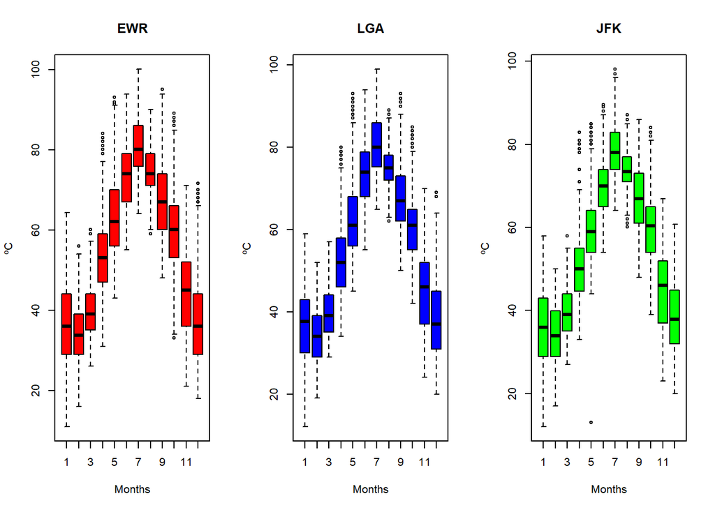

```r
par(mfrow= c(1,3))
boxplot(tiempo$temp[tiempo$origin=="EWR"]~tiempo$month[tiempo$origin=="EWR"], xlab="Months", ylab= "ºC", main="EWR", col="red")

boxplot(tiempo$temp[tiempo$origin=="LGA"]~tiempo$month[tiempo$origin=="LGA"], xlab="Months", ylab= "ºC", main="LGA", col="blue")

boxplot(tiempo$temp[tiempo$origin=="JFK"]~tiempo$month[tiempo$origin=="JFK"], xlab="Months", ylab= "ºC", main="JFK", col="green")
```

## 4. (2 puntos) El día de tu cumpleaños:

1. Qué correlación tuvieron la temperatura y humedad en cada uno de los origin? Plotealo mediante puntos con ggplot.

```r
cor(weather$temp[weather$month==10 & weather$day==15 & weather$origin=="LGA"], weather$humid[weather$month==10 & weather$day==15 & weather$origin=="LGA"])
```

```
## [1] -0.8138998
```

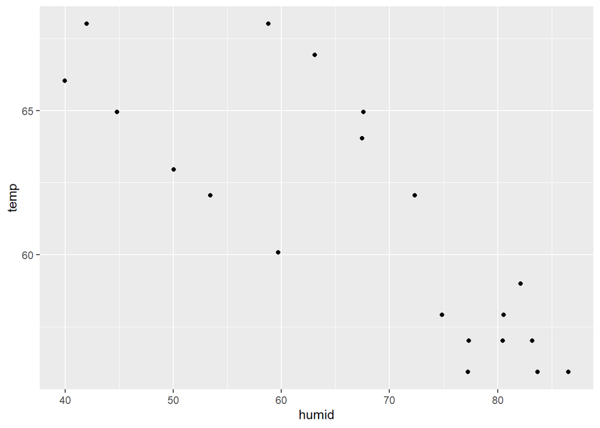

```r
cumpLGA<-filter( weather, month==10, day==15, origin=="LGA")
ggplot(data = cumpLGA) +
  geom_point(mapping = aes (x=humid, y=temp))
```

```r
cor(weather$temp[weather$month==10 & weather$day==15 & weather$origin=="EWR"], weather$humid[weather$month==10 & weather$day==15 & weather$origin=="EWR"])
```

```
## [1] -0.9624793
```

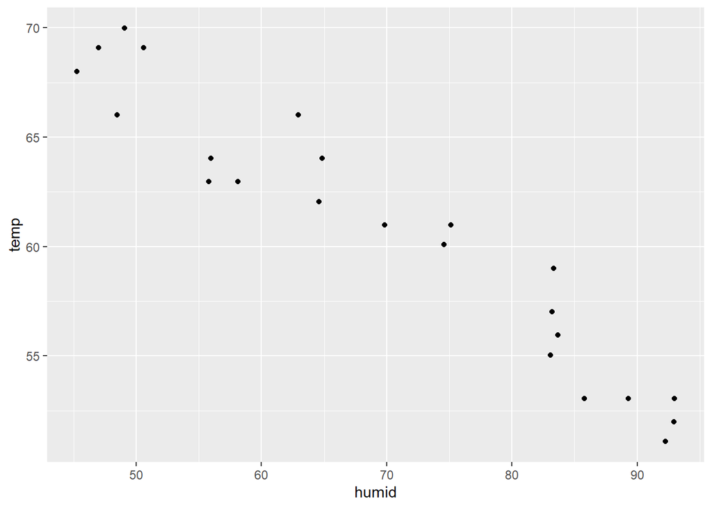

```r
cumpEWR<-filter( weather, month==10, day==15, origin=="EWR")
ggplot(data = cumpEWR) +
  geom_point(mapping = aes (x=humid, y=temp))
```

```r
cor(weather$temp[weather$month==10 & weather$day==15 & weather$origin=="JFK"], weather$humid[weather$month==10 & weather$day==15 & weather$origin=="JFK"])
```

```
## [1] -0.9611779
```

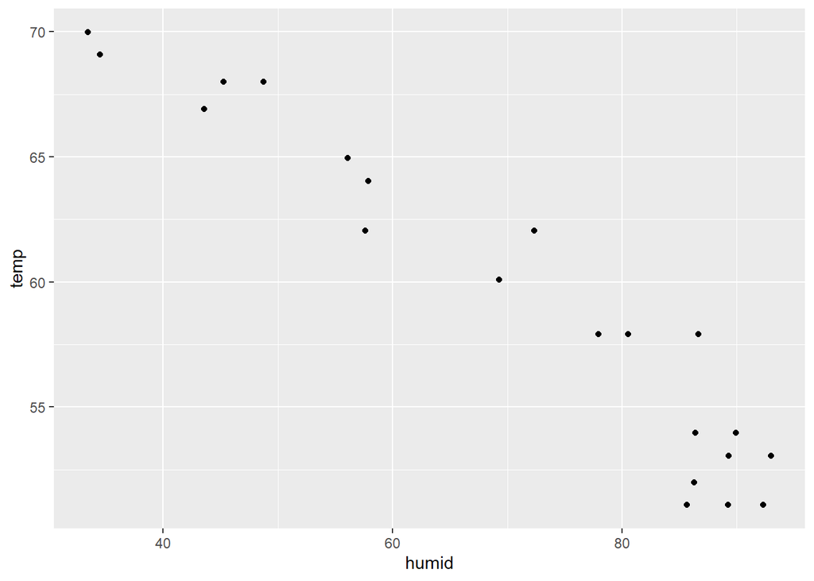

```r
cumpJFK<-filter( weather, month==10, day==15, origin=="JFK")
ggplot(data = cumpJFK) +
  geom_point(mapping = aes (x=humid, y=temp))
```

2. Si comparas la temperatura en los origins JFK y LGA ¿son estadísticamente diferentes? ¿Qué p-valor consigues? Plotea los boxplots.

```r
JFK<-filter(weather, origin=="JFK")
LGA<-filter(weather, origin=="LGA")
t.test(JFK$temp, LGA$temp)
```

```
##
##  Welch Two Sample t-test
##
## data:  JFK$temp and LGA$temp
## t = -4.869, df = 17370, p-value = 1.131e-06
## alternative hypothesis: true difference in means is not equal to 0
## 95 percent confidence interval:
##  -1.8099470 -0.7709628
## sample estimates:
## mean of x mean of y
##  54.47215  55.76261
```

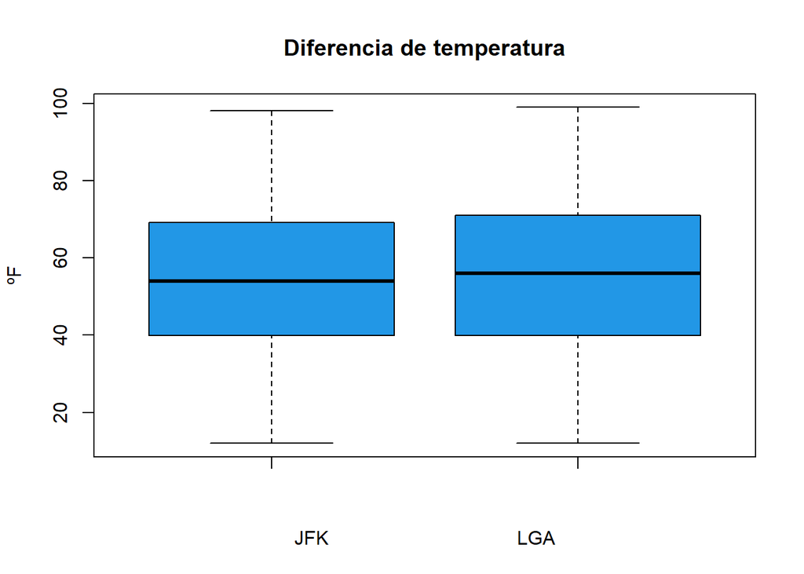

```r
# Se obtiene un valor de p=1.131e-06. Al ser menor de 0,05, podemos afirmar que es estadísticamente significativo la temperatura en los orígenes JFK y LGA.

boxplot (JFK$temp, LGA$temp, ylab= "ºF", main="Diferencia de temperatura", col="68", xlab="JFK                                   LGA")
```

```r
# El valor con mayor fold change en valores absolutos sería en este caso el gen que se encuentra en en las coordenadas -8 en el eje de logfc y 5 en el eje -log10(pvalue)
```

[output not shown]

2. ¿Qué gen sobreexpresado es el más significativo?

```r
# El gen sobreexpresado más significativo sería el Csn1s2b, pues su valor de p es el más elevado de todos (mayor valor de -log10(pvalue))
```

[output not shown]

6. (1 punto) Sube el examen a github y escribe a continuación tu url aquí.

```r
# https://github.com/Richisama/Examen_Bioinformatica.git
```